# DWEI5_Aula03_Renderizacao_Listas_Formularios-ReactJS

[figure not shown]

Instituto Federal de São Paulo (IFSP)  
[Campus Bragança Paulista/SP](https://bra.ifsp.edu.br)  
**Análise e Desenvolvimento de Sistemas (ADS)**  
**5o. módulo**  
**Profa. Ana Paula Müller Giancoli**  
paulagiancoli@ifsp.edu.br

[figure not shown]

## AULA 03 - RENDERIZAÇÃO, LISTAS, FORMULÁRIOS EM REACTJS

### Agenda

- Renderização Condicional
- Manipulando Listas
- Conhecendo Formulários
- Perguntas

### 1. Renderização Condicional

- De acordo com [React](https://pt-br.reactjs.org/docs/conditional-rendering.html), renderização condicional em React funciona do mesmo jeito que as condições funcionam em Javascript.
- Podemos utilizar operadores condicionais if, ternário.
- **Exemplo no Javascript**:

```python
**********************************
/* Exemplo de código Javascript */
**********************************

function UsuarioBemvindo(props) {
  return <h1>Bem vindo!</h1>;
}

function UsuarioNovo(props) {
  return <h1>Olá aluno, efetue o Logon!</h1>;
}
```

- Criando um componente que mostra os dois componentes indicando quando o usuário está logado ou não. Utilizando o operador ternário.
- Para verificar o uso, trocaremos na mão, o valor do state estado de **false** para **true**.

```python
*******************************************************
/* Exemplo Arquivo App.js - Renderização Condicional */
*******************************************************

import './App.css';
import React, { Component } from 'react';

class App extends Component {

    constructor(props) {
        super(props);
        this.state = {
            estado: false
        };
    }

    render(){
        return(
          <div className="App App-header">
              { this.state.estado ?
                <div>
                    <h2> Bem vindo !!</h2>
                </div> :
                <div>
                    <h2>Olá aluno, efetue o Logon!</h2>
                </div>
              }
          </div>
        );
    }
}

export default App;
```

- Adicionando um botão para mudar o estado ao ser pressionado.

```python
*****************************************************************
/* Exemplo Arquivo App.js - Renderização Condicional com botão */
*****************************************************************

import './App.css';
import React, { Component } from 'react';

class App extends Component {

    constructor(props) {
        super(props);
        this.state = {
            estado: false
        };
        this.logout = this.logout.bind(this);
        this.logon = this.logon.bind(this);
    }

    logon() {
        this.setState( { estado: true } )
    }

    logout() {
        this.setState( { estado: false } )
    }

    render(){
        return(
          <div className="App App-header">
              { this.state.estado ?
                <div>
                    <h2> Bem vindo !!</h2>
                    <button onClick= {this.logout}> Sair do Ambiente </button>
                </div> :
                <div>
                    <h2>Olá aluno, efetue o Logon!</h2>
                    <button onClick= {this.logon}> Entrar no Ambiente </button>
                </div>
              }
          </div>
        );
    }
}

export default App;
```

[figure not shown]

[figure not shown]

### 2. Manipulando Listas e Chaves

- De acordo com [React](https://pt-br.reactjs.org/docs/lists-and-keys.html), utiliza-se a função **map( )** para transformar arrays em listas.
- **Exemplo**: Utilizamos um array de objetos. Para efeitos didáticos, deixamos fixos e não buscamos de um banco de dados. Veremos mais a frente.

```python
**********************************************
/* Exemplo Arquivo App.js - Listas e Chaves */
**********************************************

import './App.css';
import React, { Component } from 'react';

class App extends Component {

    constructor(props) {
        super(props);
        this.state = {
            listagem: [
                {id: 1, nome: 'Ana Paula', sobrenome: 'Müller', idade: 47, disciplinas: 4},
                {id: 2, nome: 'Ana Paula', sobrenome: 'Giancoli', idade: 27, disciplinas: 14},
                {id: 3, nome: 'Ana', sobrenome: 'Müller', idade: 20, disciplinas: 10},
                {id: 4, nome: 'Ana', sobrenome: 'Giancoli', idade: 97, disciplinas: 3},
                {id: 5, nome: 'Paula', sobrenome: 'Müller', idade: 55, disciplinas: 2},
                {id: 6, nome: 'Paula', sobrenome: 'Giancoli', idade: 22, disciplinas: 42}
            ]
        };
    }

    render(){
        return(
          <div className="App">
              { this.state.listagem.map((item) => {
                  return(
                    <div>
                        <h3>Identificação: { item.id } | Nome completo: {item.nome} { item.sobrenome } </h3>
                        <p>Idade: { item.idade } anos / Quantidade: { item.disciplinas } disciplinas</p>
                    </div>
                  )
              })
              }
              </div>
        );
    }
}

export default App;
```

[figure not shown]

- **Observação**:
- Ao inspecionarmos a página, veremos o seguinte erro:

[figure not shown]

```python
***********************************************
/* Exemplo Estrutura básica de um Componente */
***********************************************

import React, { Component } from 'react';

class Listagem extends Component {

    render(){
        return(
            <div>

            </div>
        );
    }
}

export default Listagem;
```

- Lembrando que **props** é passada automaticamente para a classe.
- E para utilizar, basta inserir o this.props.**atributo**.
- Completando a classe **Listagem**. E adequando **App.js**.

```python
*************************************************************
/* Exemplo Arquivo Listagem.js - src/component/Listagem.js */
*************************************************************

import React, { Component } from 'react';

class Listagem extends Component {

    render(){
        return(
            <div key={ this.props.id } >
                <p><strong>Nome completo:</strong> { this.props.nome} { this.props.sobrenome } |
                    <strong>idade:</strong> { this.props.idade } anos, e { this.props.disciplinas }
                    disciplinas.</p>
            </div>
        );
    }
}

export default Listagem;
```

```python
****************************
/* Exemplo Arquivo App.js */
****************************

import './App.css';
import React, { Component } from 'react';
import Listagem from './components/Listagem';

class App extends Component {

    constructor(props) {
        super(props);
        this.state = {
            listagem: [
                {id: 1, nome: 'Ana Paula', sobrenome: 'Müller', idade: 47, disciplinas: 4},
                {id: 2, nome: 'Ana Paula', sobrenome: 'Giancoli', idade: 27, disciplinas: 14},
                {id: 3, nome: 'Ana', sobrenome: 'Müller', idade: 20, disciplinas: 10},
                {id: 4, nome: 'Ana', sobrenome: 'Giancoli', idade: 97, disciplinas: 3},
                {id: 5, nome: 'Paula', sobrenome: 'Müller', idade: 55, disciplinas: 2},
                {id: 6, nome: 'Paula', sobrenome: 'Giancoli', idade: 22, disciplinas: 42}
            ]
        };
    }

    render(){
        return(
          <div className="App">
              { this.state.listagem.map((item) => {
                  return(
                    <Listagem key={ item.id }  nome = {item.nome} sobrenome = { item.sobrenome }
                      idade = { item.idade } disciplinas ={ item.disciplinas } />
                  );
              })
              }
          </div>
        );
    }
}

export default App;
```

[figure not shown]

### 3. Conhecendo Formulários

- De acordo com [React](https://pt-br.reactjs.org/docs/forms.html), o funcionamento dos elementos de formulário HTML é um pouco diferente de outros elementos DOM no React. Mantêm algum estado interno.
- **Exemplo** no HTML:

```python
************************************************
/* Exemplo Simplificado de formulário no HTML */
************************************************

<form>
  <label>
    Nome: <input type="text" name="nome" />
  </label>
  <input type="submit" value="Enviar" />
</form>
```

- Ainda segundo [React]: "*Esse formulário tem o comportamento padrão do HTML de navegar para uma nova página quando o usuário enviar o formulário. Se você quer esse comportamento no React, ele simplesmente funciona. Mas na maioria dos casos, é conveniente ter uma função JavaScript que manipula o envio de um formulário e tem acesso aos dados que o usuário digitou nos inputs. O modo padrão de fazer isso é com uma técnica chamada “componentes controlados” (controlled components)*."

```python
*********************
/* Arquivo App.js */
*********************

import './App.css';
import React, { Component } from 'react';

class App extends Component {

    constructor(props) {
        super(props)
        this.state = {
          nome: 'Ana Giancoli',
          sexo: 'feminino',
          email: "paulagiancoli@ifsp.edu.br",
          senha: "1234"
        };
    }

    render(){
        return(
          <div className="App">
              <header className="App-header">
                <h1>Registro de Entrada</h1>
              </header>
              <div>
                  <form className="App-div">
                        <p>
                            <label htmlFor="sexo">Sexo: </label>
                            <select name="sexo" id="sexo">
                                <option value="selecione">Selecione</option>
                                <option value="masculino">Masculino</option>
                                <option value="feminino">Feminino</option>
                            </select>
                        </p>
                        <p>
                            <label htmlFor="nome">Nome Completo: </label>
                            <input className="App-Form-Item" type="text" name="nome" id="nome" value={ this.state.nome }/>
                        </p>
                        <p>
                            <label htmlFor="email">E-mail: </label>
                            <input className="App-Form-Item" type="email" name="email" id="email" value={ this.state.email }/>
                        </p>
                        <p>
                            <label htmlFor="senha">Senha: </label>
                            <input className="App-Form-Item" type="password" name="senha" id="senha" value={ this.state.senha }/>
                        </p>
                  </form>
              </div>
          </div>
        );
    }
}

export default App;
```

```python
*********************************
/* Arquivo App.css */ Modificado
*********************************

.App {
  text-align: center;
}

.App-logo {
  height: 40vmin;
  pointer-events: none;
}

@media (prefers-reduced-motion: no-preference) {
  .App-logo {
    animation: App-logo-spin infinite 20s linear;
  }
}

.App-header {
  background-color: #282c34;
  min-height: 8vh;
  font-size: calc(10px + 2vmin);
  color: white;
}

.App-link {
  color: #61dafb;
}

.App-div {
  background-color: #698485;
  display: flex;
  flex-direction: column;
  align-items: flex-end;
  padding: 20px;
  margin: 10px auto;
  color: white;
}

.App-Form-Item {
  border-radius: 4px;
  outline: auto;
}

@keyframes App-logo-spin {
  from {
    transform: rotate(0deg);
  }
  to {
    transform: rotate(360deg);
  }
}
```

- **Saída**

[figure not shown]

- Neste exemplo é possível perceber que ao tentarmos alterar algo, não conseguimos, pois estamos passando um valor fixo: **value = { this.state.nome }** por exemplo.
- Para que reconheça a alteração de valores, utilizaremos o método **onChange( )**.
- Todas as vezes que alterarmos o valor de algum campo, ao clicarmos sobre ele, será executado o **onChange( )**.
- Podemos fazer isso de duas formas:
  - **Primeira**: Criando a função externa, recebendo um evento que por meio dele poderemos acessar o valor digitado: **e.target.value**, e alterando a **state** por meio do método **setState**. (Exemplo do nome e email)
  - **Segundo**: Criando na própria chamada do **onChange( )**. Usando uma **função anônima** que recebe o evento, e alterando o **state** localmente, sem necessidade de chamar uma **função externa**. (Exemplo da Senha e sexo)
    - **onChange={ (e) => this.setState({ senha: e.target.value }) }**

```python
***********************************************
/* Arquivo App.js com os métodos onChange( ) */
***********************************************

import './App.css';
import React, { Component } from 'react';

class App extends Component {

    constructor(props) {
        super(props)
        this.state = {
          nome: '',
          sexo: '',
          email: "",
          senha: ""
        };

        this.trocarNome = this.trocarNome.bind(this);
        this.trocarEmail = this.trocarEmail.bind(this);
    }

    trocarNome(e){
        let nomedigitado = e.target.value;
        this.setState({ nome: nomedigitado });
    }

    trocarEmail(e){
        let emaildigitado = e.target.value;
        this.setState({ email: emaildigitado });
    }

    render(){
        return(
          <div className="App">
              <header className="App-header">
                <h1>Registro de Entrada</h1>
              </header>
              <div>
                  <form className="App-div">
                    <p>
                        <label htmlFor="sexo">Sexo: </label>
                        <select name="sexo" id="sexo" value= { this.state.sexo }
                            onChange={ (e) => this.setState({ sexo: e.target.value }) }>
                            <option value="selecione">Selecione</option>
                            <option value="masculino">Masculino</option>
                            <option value="feminino">Feminino</option>
                        </select>
                    </p>
                    <p>
                        <label htmlFor="nome">Nome Completo: </label>
                        <input className="App-Form-Item" type="text" name="nome" id="nome" value={ this.state.nome }
                        onChange={ this.trocarNome }/>
                    </p>
                    <p>
                        <label htmlFor="email">E-mail: </label>
                        <input className="App-Form-Item" type="email" name="email" id="email" value={ this.state.email }
                        onChange={ this.trocarEmail }/>
                    </p>
                    <p>
                        <label htmlFor="senha">Senha: </label>
                        <input className="App-Form-Item" type="password" name="senha" id="senha" value={ this.state.senha }
                        onChange={ (e) => this.setState({ senha: e.target.value }) }/>
                    </p>
                  </form>
              </div>
          </div>
        );
    }
}

export default App;
```

- Com estas modificações, conseguimos alterar os valores informados nos campos do formulário.
- Para validação, incluir as linhas indicadas abaixo dentro da **div** do **return( )**. Ou poderia enviar para o **{ console.log(this.state.nome) }**.

```python
************************************************************
/* Arquivo App.js adequação para validar dados digitados  */
************************************************************
...

              <div>
                  <h5>{ this.state.nome }</h5>
                  <h5>{ this.state.sexo }</h5>
                  <h5>{ this.state.email }</h5>
                  <h5>{ this.state.senha }</h5>
              </div>
          </div>
        );
    }
}

export default App;
```

```python
************************************************************
/* Arquivo App.js adequação para validar dados digitados  */
************************************************************
...

              <div>
                  <h5>{ console.log(this.state.nome) }</h5>
                  <h5>{ console.log(this.state.sexo) }</h5>
                  <h5>{ console.log(this.state.email) }</h5>
                  <h5>{ console.log(this.state.senha) }</h5>
              </div>
          </div>
        );
    }
}

export default App;
```

- **Saída**

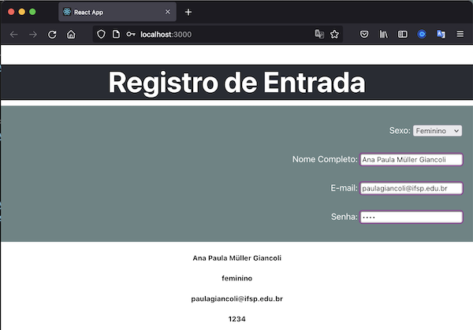

### 3.1. Melhorando nosso Formulário

- Vamos adicionar um **botão** para enviá-lo do **tipo submit**.
- Da mesma forma que utilizamos o **onChange( )**, para o botão enviar o formulário, utilizaremos o **onSubmit( )**, porém na tag do formulário. Podemos chamar uma função externa.
- Adequando todos os campos para uso de função anônima.
- Inserindo **onSubmit( )** no **form**.
- Será criada uma função **registrar( )** que emitirá um **alert( )**, somente para verificarmos o funcionamento.
- Utilizaremos **templates string** ( **\${ }** ) para facilitar o uso das informações de javascript.
- Na função **registrar( )**, para verificarmos se as informações estão sendo passadas de forma correta, criaremos uma **const** com as variáveis para cada um dos **states**.
- Adicionaremos o **e.preventDefault( )**, que serve para não atualizar a página após o preenchimento e envio.
- E adicionaremos também a verificação se todos os campos estão preenchidos. Exibirá um erro se não estiverem preenchidos.
- Se o **state erro** tiver **algum valor**, o React renderizará a mensagem de erro antes do formulário por meio desta validanção : **{ this.state.erro && < p> { this.state.erro } < /p>}**. Senão, não exibe.

```python
*************************************************************************
/* Arquivo App.css adequação para exibir a mensagem de erro  destacada */
*************************************************************************

.App-erro {
  background-color: #e43838;
  color: #fff;
  padding: 10px;
  margin: auto 200px;
  border-radius: 5px;
}
```

```python
****************************************************************************
/* Arquivo App.js aplicando todas as adequações mencionadas anteriormente */
****************************************************************************

import './App.css';
import React, { Component } from 'react';

class App extends Component {

    constructor(props) {
        super(props)
        this.state = {
          nome: '',
          sexo: '',
          email: '',
          senha: '',
          erro: ''
        };
        this.registrar = this.registrar.bind(this);
    }

    registrar(e) {
        alert("Enviando ...");
        const { nome, sexo, email, senha } = this.state;

        if (nome !== '' && sexo !== '' && email !== '' && senha !== '') {
            alert(`Nome: ${nome} \nSexo: ${sexo} \nEmail: ${email} \nSenha: ${senha}`);
        } else {
            this.setState( { erro: 'Faltou o preenchimento de algum campo! '});
        }

        e.preventDefault();
    }

    render(){
        return(
          <div className="App">
              <header className="App-header">
                <h1>Registro de Entrada</h1>
              </header>
              <div>

                  { this.state.erro && <h5 className="App-erro"> { this.state.erro } </h5>}

                  <form className="App-div" onSubmit={ this.registrar }>
                    <p>
                        <label htmlFor="sexo">Sexo: </label>
                        <select name="sexo" id="sexo" value= { this.state.sexo }
                            onChange={ (e) => this.setState({ sexo: e.target.value }) }>
                            <option value="selecione">Selecione</option>
                            <option value="masculino">Masculino</option>
                            <option value="feminino">Feminino</option>
                        </select>
                    </p>
                    <p>
                        <label htmlFor="nome">Nome Completo: </label>
                        <input className="App-Form-Item" type="text" name="nome" id="nome" value={ this.state.nome }
                        onChange={ (e) => this.setState({ nome: e.target.value }) }/>
                    </p>
                    <p>
                        <label htmlFor="email">E-mail: </label>
                        <input className="App-Form-Item" type="email" name="email" id="email" value={ this.state.email }
                        onChange={ (e) => this.setState({ email: e.target.value }) }/>
                    </p>
                    <p>
                        <label htmlFor="senha">Senha: </label>
                        <input className="App-Form-Item" type="password" name="senha" id="senha" value={ this.state.senha }
                        onChange={ (e) => this.setState({ senha: e.target.value }) }/>
                    </p>
                    <p>
                        <button type="submit">Enviar</button>
                    </p>
                  </form>
              </div>

              <div>
                  <h5>{ this.state.nome }</h5>
                  <h5>{ this.state.sexo }</h5>
                  <h5>{ this.state.email }</h5>
                  <h5>{ this.state.senha }</h5>
              </div>
          </div>
        );
    }
}

export default App;
```

- Preenchendo todos os campos. E selecionando Enviar.

[figure not shown]

- Mensagem alert antes do envio.

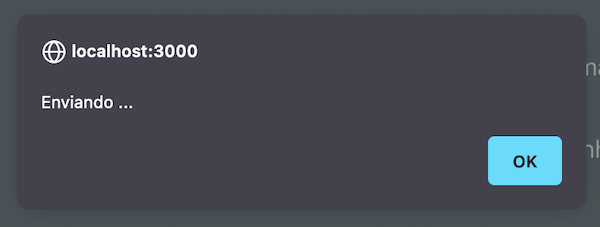

- Mensagem alert com as informações enviadas.

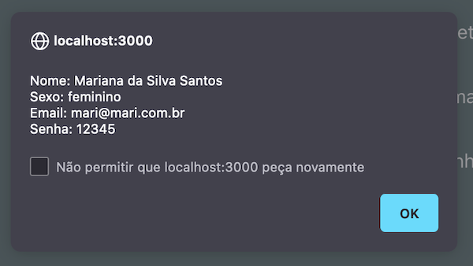

- Mensagem de erro exibida, caso algum dos campos não esteja preenchido.

[figure not shown]

### 3.2. Otimizando o Formulário

- Imagine se tivesse que efetuar a manutenção de frormulários com diversos campos e para cada campo, tivesse que criar uma função, igual fizemos anteriormente?
- Seria inviável.
- Então, vamos unificar tudo em **uma única função do formulário -- formInfo( )**.
- Ao invés de criarmos **states separadas** para cada um dos valores, podemos criar um **objeto**.
- Adequando o exemplo anterior:

```python
****************************************************************************
/* Arquivo App.js aplicando todas as adequações mencionadas anteriormente */
****************************************************************************

import './App.css';
import React, { Component } from 'react';

class App extends Component {

    constructor(props) {
        super(props)
        this.state = {
            form: {
                nome: '',
                sexo: '',
                email: '',
                senha: ''
            },
            erro: ''
        };
        this.registrar = this.registrar.bind(this);
        this.formInfo = this.formInfo.bind(this);
    }

    registrar(e) {

        alert("Enviando ...");
        const { nome, sexo, email, senha } = this.state.form;

        if (nome !== '' && sexo !== '' && email !== '' && senha !== '') {
            alert(`Nome: ${nome} \nSexo: ${sexo} \nEmail: ${email} \nSenha: ${senha}`);
        } else {
            this.setState( { erro: 'Faltou o preenchimento de algum campo! '});
        }

        e.preventDefault();
    }

    formInfo(e) {
        let form = this.state.form;
        form[e.target.name] = e.target.value;
        this.setState({form: form});
    }


    render(){
        return(
          <div className="App">
              <header className="App-header">
                <h1>Registro de Entrada</h1>
              </header>
              <div>

                  { this.state.erro && <h5 className="App-erro"> { this.state.erro } </h5>}

                  <form className="App-div" onSubmit={ this.registrar }>
                    <p>
                        <label htmlFor="sexo">Sexo: </label>
                        <select name="sexo" id="sexo" value= { this.state.form.sexo }
                            onChange={ this.formInfo }>
                            <option value="selecione">Selecione</option>
                            <option value="masculino">Masculino</option>
                            <option value="feminino">Feminino</option>
                        </select>
                    </p>
                    <p>
                        <label htmlFor="nome">Nome Completo: </label>
                        <input className="App-Form-Item" type="text" name="nome" id="nome" value={ this.state.form.nome }
                        onChange={ this.formInfo }/>
                    </p>
                    <p>
                        <label htmlFor="email">E-mail: </label>
                        <input className="App-Form-Item" type="email" name="email" id="email" value={ this.state.form.email }
                        onChange={ this.formInfo }/>
                    </p>
                    <p>
                        <label htmlFor="senha">Senha: </label>
                        <input className="App-Form-Item" type="password" name="senha" id="senha" value={ this.state.form.senha }
                        onChange={ this.formInfo }/>
                    </p>
                    <p>
                        <button type="submit">Enviar</button>
                    </p>
                  </form>
              </div>

              <div>
                  <h5>{ this.state.form.nome }</h5>
                  <h5>{ this.state.form.sexo }</h5>
                  <h5>{ this.state.form.email }</h5>
                  <h5>{ this.state.form.senha }</h5>
              </div>
          </div>
        );
    }
}

export default App;
```

### Referências

- Esta aula foi elaborada a partir do conteúdo disponibilizado em cada um dos links indicados no próprio texto.

### Perguntas

- Esclareça suas eventuais dúvidas durante as aulas.
- Ou pelo *E-mail*: paulagiancoli@ifsp.edu.br.
- Ou acesse [Github Ana Giancoli](https://anagiancoli.github.io) e solicite atendimento para o componente curricular.

*ADS - HTML5, CSS3, JS, React, AWS - 5o. módulo*.  
Modelo e formato elaborado por profa. Ana Paula Müller Giancoli - BSD 2-Clause License. - Julho.2021.